# FSVariables

Rolando

2/21/2020

## 文件目的

- 此文件是為了整理所有IPO公司興櫃期間的財務比率變數，主要計算：
1. IPO公司與同市場產業平均比較，可做成比值描述，例如：短期償債能力相對於產業平均來說優於或低於幾倍。

## 整理產業別

- 由於有數間公司可能因為全額交割股、下市櫃..等因素導致TEJ將其產業資料刪除，因此直接由TSE或是鉅亨網…等抓取他們的產業別。

```r
AdjustIndustry <- function(...){
  `TSE新產業名_new` <- c("M1100 水泥工業", "M1200 食品工業", "M2000 鋼鐵工業", "M1200 食品工業",
                   "M1200 食品工業", "M1200 食品工業", "M1200 食品工業", "M1100 水泥工業",
                   "M1200 食品工業", "M1200 食品工業", "M9900 其他", "M1400 紡織纖維" ,
                   NA ,              "M1400 紡織纖維", "M1400 紡織纖維", "M1200 食品工業",
                   "M1400 紡織纖維", "M1400 紡織纖維", "M1500 電機機械",  "M1500 電機機械",
                   "M1500 電機機械", "M1722 生技醫療", "M2500 建材營造", "M1900 造紙工業",
                   "M2000 鋼鐵工業", "M2000 鋼鐵工業", "M2000 鋼鐵工業", "M2300 電子工業",
                   "M2300 電子工業", "M2325 電腦及週邊", "M2300 電子工業", "M2327 通信網路業",
                   "M2300 電子工業", "M2300 電子工業", "M2300 電子工業", "M2300 電子工業",
                   "M2328 電子零組件", "M2300 電子工業", "M2300 電子工業", "M2300 電子工業",
                   "M2300 電子工業", "M2300 電子工業", "M2328 電子零組件", "M2300 電子工業",
                   "M2300 電子工業", "M2300 電子工業", "M2327 通信網路業", "M2300 電子工業",
                   "M2300 電子工業", "M2330 資訊服務業", "M2325 電腦及週邊", "M2325 電腦及週邊",
                   "M2500 建材營造", "M2500 建材營造", "M2500 建材營造", "M2500 建材營造",
                   "M2500 建材營造", "M2500 建材營造", "M2326 光電業", "M2500 建材營造",
                   "M2500 建材營造", "M2600 航運業", "M2700 觀光事業", "M2800 金融業",
                   "M2800 金融業", "M2800 金融業", "M2800 金融業", "M2800 金融業",
                   "M2800 金融業", "M2800 金融業", "M2800 金融業", "M2800 金融業",
                   "M2800 金融業", "M2800 金融業", "M2800 金融業", "M2800 金融業",
                   "M2325 電腦及週邊", "M2328 電子零組件", "M2300 電子工業", "M2325 電腦及週邊",
                   "M2328 電子零組件", "M2324 半導體", "M2326 光電業", "M2326 光電業",
                   "M2328 電子零組件", "M1722 生技醫療", "M1400 紡織纖維", "M1400 紡織纖維",
                   "M1500 電機機械", "M2000 鋼鐵工業", "M2328 電子零組件", "M2328 電子零組件",
                   "M2000 鋼鐵工業", "M2330 資訊服務業", "M2330 資訊服務業", "M2330 資訊服務業",
                   "M2300 電子工業", NA,                 "M2325 電腦及週邊", "M2324 半導體",
                   "M2300 電子工業", "M2300 電子工業" , "M2300 電子工業", "M2330 資訊服務業",
                   "M2324 半導體", "M2325 電腦及週邊", "M2300 電子工業", "M2324 半導體",
                   "M2325 電腦及週邊", "M2300 電子工業", "M2500 建材營造", "M2500 建材營造",
                   "M2325 電腦及週邊", "M2328 電子零組件", "M2500 建材營造", "M2600 航運業",
                   "M2700 觀光事業", "M2800 金融業", "M2800 金融業", "M2800 金融業",
                   "M2800 金融業", "M2328 電子零組件", "M2300 電子工業", "M2300 電子工業",
                   "M2328 電子零組件", "M2328 電子零組件", "M2324 半導體", "M2326 光電業",
                   "M2328 電子零組件", "M2330 資訊服務業", "M2330 資訊服務業", "M2300 電子工業",
                   "M2326 光電業", "M2326 光電業", "M2300 電子工業", "M1722 生技醫療",
                   "M9900 其他", "M2200 汽車工業", "M2300 電子工業", "M2000 鋼鐵工業",
                   "M2500 建材營造", NA,           "M2200 汽車工業", "M1300 塑膠工業",
                   "M9900 其他", "M2500 建材營造", "M1500 電機機械", "M9900 其他",
                   "M1200 食品工業", NA,           "M1200 食品工業", "M2500 建材營造",
                   "M2900 貿易百貨", "M9900 其他", "M2325 電腦及週邊")
  return(`TSE新產業名_new`)
}

FirmWithoutIndustry <- FS_AllFirms %>%
  setDT() %>%
  setnames(., old = "公司", new = "公司簡稱") %>%
  .[is.na(`TSE新產業名`) == T] %>%
  .[, tail(.SD, 1), by = "公司簡稱"] %>%
  .[, 1] %>%
  cbind(., AdjustIndustry()) %>%
  setnames(., old = "V2", new = "TSE新產業名_new")

FS_AllFirms_Data <- FS_AllFirms %>%
  setDT() %>%
  setnames(., old = "公司", new = "公司簡稱") %>%
  .[order(`公司簡稱`, `年月`)] %>%
  .[, `:=` (`季別` = zoo::as.yearqtr(`年月`, format = "%Y-%m-%d"))] %>%
  left_join(., FirmWithoutIndustry, by = "公司簡稱") %>%
  setDT() %>%
  .[, `TSE新產業名` := ifelse(`公司簡稱` %in% FirmWithoutIndustry$公司簡稱,
                          `TSE新產業名_new`, `TSE新產業名`)] %>%
  .[, .SD, .SDcols = -c("TSE新產業名_new")]

FS_ListFirm_Data <- FS_AllFirms_Data %>%
  .[`公司簡稱` %in% ListFirm$公司簡稱]
```

## 計算所有財務比率

```r
CaculateFSVariable <- function(Data){

  # 總資產成長率
TotalAssetGrowthRate <- Data %>%
  .[, .SD, .SDcols = c("公司簡稱", "TSE新產業名", "季別", "資產總額")] %>%
  .[str_sub(`季別`, 6, 7) == "Q4"] %>%
  .[, `:=` (`總資產成長率` = ((`資產總額` - lag(`資產總額`)) / lag(`資產總額`))*100),
    by = "公司簡稱"] %>%
  .[, .SD, .SDcols = c("公司簡稱", "TSE新產業名", "季別", "總資產成長率")]

### 計算週轉率 Var1 代表公式的分子變數 Var2代表公式的分母變數 建立完成後記得重新命名變數名稱
CaculateTrunOverRatio <- function(Data, Var1, Var2){
  Result <- Data %>%
    .[, .SD, .SDcols = c("公司簡稱", "TSE新產業名", "季別", Var1, Var2)] %>%
    .[str_sub(`季別`, 6, 7) == "Q4"] %>%
    .[, `:=` (NewCol = get(Var1) / ((get(Var2) + lag(get(Var2)))/2)), by = "公司簡稱"] %>%
    .[, .SD, .SDcols = c("公司簡稱", "TSE新產業名", "季別", "NewCol")]
  return(Result)
}

# test <- CaculateTrunOverRatio(Data, "營業成本", "應付帳款及票據") %>%
#   setnames(., old = "NewCol", new = "應付帳款週轉率")

# 不動產、廠房及設備週轉率 (property, plant and equipment {=PPE})
PPETurnoverRatio <- CaculateTrunOverRatio(Data,
                                          "營業收入淨額", "不動產廠房及設備") %>%
  setnames(., old = "NewCol", new = "不動產、廠房及設備週轉率")

# 權益週轉率
EquityTurnoverRatio <- CaculateTrunOverRatio(Data,
                                             "營業收入淨額", "股東權益總額") %>%
  setnames(., old = "NewCol", new = "權益週轉率")

# 營運資金週轉率
WorkingCapitalTrunoverRatio <- Data %>%
  .[, .SD, .SDcols = c("公司簡稱", "TSE新產業名", "季別",
                       "營業收入淨額", "流動資產", "流動負債")] %>%
  .[, `:=` (`營運資金週轉率` = `營業收入淨額` / (`流動資產` - `流動負債`)), by = "公司簡稱"] %>%
  .[, .SD, .SDcols = c("公司簡稱", "TSE新產業名", "季別", "營運資金週轉率")]

# 其他財務比率
FinancialRatioData_WithOutJoin <- Data %>%
  .[, `:=` (`長期資金佔不動產、廠房及設備比率(%)` = ((`非流動負債`+ `股東權益總額`)/`不動產廠房及設備`)*100,
            `不動產、廠房及設備週轉率(次)` = (`營業利益`/ `不動產廠房及設備`),
            `不動產、廠房及設備比率` = (`不動產廠房及設備` / `資產總額`)*100,
            `不動產、廠房及設備對權益比率` = (`不動產廠房及設備` / `股東權益總額`)*100,
            `營運資金對總資產比率` = ((`流動資產` - `流動負債`) / `資產總額`)*100,
            `保留盈餘對總資產比率` = (`保留盈餘` / `資產總額`)*100)] %>%
  .[, .SD, .SDcols = c("公司簡稱", "TSE新產業名", "季別", "長期資金佔不動產、廠房及設備比率(%)",
                       "不動產、廠房及設備週轉率(次)", "不動產、廠房及設備比率",
                       "不動產、廠房及設備對權益比率", "營運資金對總資產比率",
                       "保留盈餘對總資產比率")]

JoinListForFinancialRatio <- list(Data, FinancialRatioData_WithOutJoin,
                                  TotalAssetGrowthRate, PPETurnoverRatio, EquityTurnoverRatio,
                                  WorkingCapitalTrunoverRatio)

# 模型需要的財務比率變數
FinancialStructureVar <- c("負債比率", "長期資金佔不動產、廠房及設備比率(%)", "不動產、廠房及設備比率",
                           "不動產、廠房及設備對權益比率", "內部保留比率")
SolvencyVar <- c("流動比率", "利息保障倍數")
OperatingAbilityVar <- c("應收帳款週轉次數", "存貨週轉率（次）",
                         "不動產、廠房及設備週轉率(次)", "總資產週轉次數",
                         "總資產成長率", "權益週轉率", "營運資金週轉率", "營業費用率",
                         "研究發展費用率")
ProfitabilityVar <- c("ROA(C)稅前息前折舊前",  "ROE(B)－常續利益", "常續性EPS",
                      "營業利益成長率", "營業利益率", "營收成長率", "貝里比率",
                      "股利支付率",  "當季季底P/E", "當季季底P/B")
CashFlowVar <- c("現金流量比率", "現金流量允當比", "現金再投資比")
BalanceVar <- c("營運槓桿度", "財務槓桿度")

FinancialStatementVar <- c("公司簡稱", "TSE新產業名", "季別", FinancialStructureVar, SolvencyVar, OperatingAbilityVar, ProfitabilityVar, CashFlowVar, BalanceVar)

# FinancialRatioData Final Data
FinancialRatioData <- plyr::join_all(JoinListForFinancialRatio,
                                     by = c("公司簡稱", "TSE新產業名", "季別"),
                                     type = 'left', match = "all") %>%
  setDT() %>%
  .[order(`公司簡稱`, `TSE新產業名`, `季別`)] %>%
  .[, .SD, .SDcols = FinancialStatementVar] %>%
  .[, `研究發展費用率` := ifelse(is.na(`研究發展費用率`) == T, 0, `研究發展費用率`)]

return(FinancialRatioData)

}

FinalcialVariable_AllFirm <- CaculateFSVariable(FS_AllFirms_Data) %>%
  left_join(., AllFirm_Market, by = "公司簡稱") %>%
  select(1, "Market", everything()) %>%
  setDT() %>%
  .[, Market := ifelse(`公司簡稱` %in% FirmWithMarket_Hand$公司簡稱,
                       FirmWithMarket_Hand$Market, Market)]

###  抓出共有153家公司沒有上市別資料記錄在AllFirm_Market中，因此特別存出去tej中額外找
# FirmWithoutMarket <- FinalcialVariable_AllFirm %>%
#   .[is.na(Market) == T] %>%
#   pull(公司簡稱) %>%
#   unique() %>%
#   as.data.frame()

# write.csv(FirmWithoutMarket, "Data/FirmWithoutMarket.csv")

# 計算所有樣本的財務比率 並未抓取IPO前最後一季
FinalcialVariable_ListFirm <- CaculateFSVariable(FS_ListFirm_Data)
```

## 其他財務資料

- Dividend
1. 計算IPO前最後一季財報，是否有發放股利，若有發放則為1，沒有則為0。
2. 透過IPO Fail or not 區分後發現，IPOFail的公司相對來說有比較高的比例不發放股利。
3. 建立 **Dividend_ToJoin** 以便合併入最終data中。

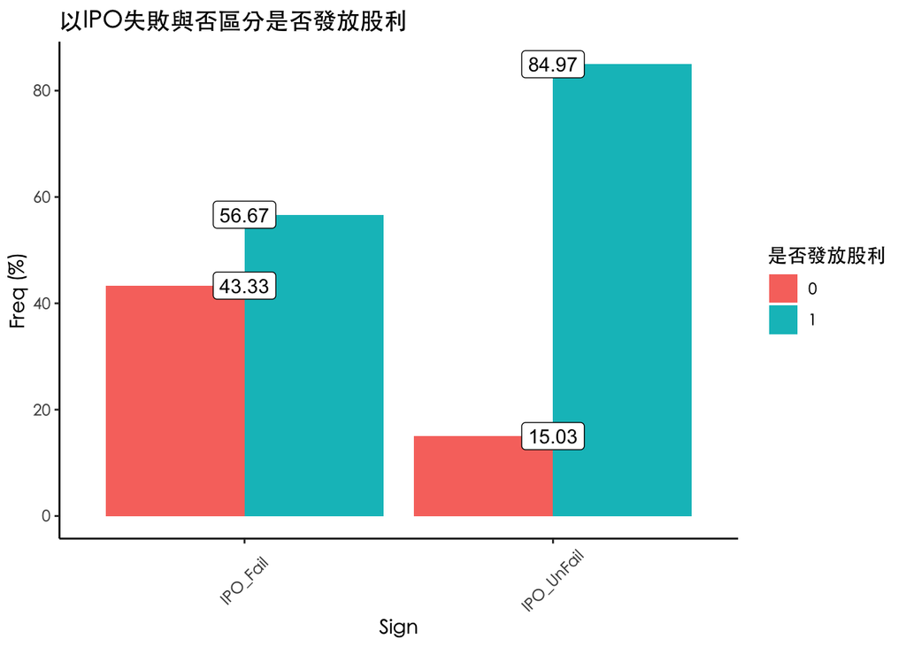

```r
## Dividend
Dividend_Data <- FS_AllFirms_Data %>%
  .[, .SD, .SDcols = c("公司簡稱", "年月" , "期末普通股－現金股利")] %>%
  .[公司簡稱 %in% ListFirm$公司簡稱] %>%
  left_join(., ListFirm %>%
              .[, .SD, .SDcols = c("公司簡稱", "上市櫃日期", "IPOFail")]
             , by = "公司簡稱") %>%
  setDT() %>%
  .[year(`上市櫃日期`) -1 == year(年月)] %>%
  .[, tail(.SD, 1), by = "公司簡稱"] %>%
  .[, `Dividend_Dummy` := ifelse(`期末普通股－現金股利` == 0, 0, 1)]

Dividend_SummaryTable <- GetTableGroupByIPOFailOrNot(Dividend_Data, "Dividend_Dummy") %>%
  setnames(., "是否大於平均", "是否發放股利")

# 畫圖顯示 Dividend_SummaryTable
Dividend_SummaryTable %>%
  ggplot(., aes(x = `Sign`, y = `Freq(%)`)) +
  geom_bar(aes(x = `Sign`, y = `Freq(%)`, fill = 是否發放股利),
           stat = "identity", position = "dodge") +
  geom_label(aes(x = `Sign`, y = `Freq(%)`, label = `Freq(%)`)) +
  ggtitle("以IPO失敗與否區分是否發放股利")+
  ylab("Freq (%)")+
  theme_classic() +
  theme(axis.text.x = element_text(vjust = 0.5, angle = 45),
        text = element_text(family="黑體-繁 中黑"),
        plot.background  = element_rect(fill = "white"),
        panel.background = element_rect(fill = "white"),
        legend.background = element_rect(fill = "white"))
```

```r
## data to join
Dividend_ToJoin <- Dividend_Data %>%
  .[, .SD, .SDcols = c("公司簡稱", "Dividend_Dummy")]
```

- Investment
1. 總共有三個變數可以考慮，**投資活動之現金流量、新增投資－CFI、購置不動產廠房設備（含預付）－CFI** ，最後使用 **投資活動之現金流量**。
2. 以Summary結果來看，IPOFail 的公司平均來說會有比較高的投資活動之現金流量。
3. 建立 **Investment_ToJin** 以便合併入最終data中。

```r
Investment <- FS_AllFirms_Data %>%
  .[, .SD, .SDcols = c("公司簡稱", "年月", "投資活動之現金流量", "購置不動產廠房設備（含預付）－CFI")] %>%
  .[公司簡稱 %in% ListFirm$公司簡稱] %>%
  left_join(., ListFirm %>%
              .[, .SD, .SDcols = c("公司簡稱", "上市櫃日期", "IPOFail")]
             , by = "公司簡稱") %>%
  setDT() %>%
  .[year(`上市櫃日期`) -1 == year(年月)] %>%
  .[, tail(.SD, 1), by = "公司簡稱"] %>%
  .[, `投資活動之現金流量` := log(`投資活動之現金流量`*(-1)+1)]
GetSummaryGroupByIPOFailAndTotal(Investment, "投資活動之現金流量")
```

```
##    投資活動之現金流量   n     mean   median      min      max     range
## 1:              Total 600 11.52341 11.52892 5.683580 17.15993 11.476346
## 2:         IPO_NoFail 545 11.50985 11.52661 6.801283 17.15993 10.358643
## 3:           IPO_Fail  55 11.65775 11.64354 5.683580 15.23637  9.552788
##          skew  kurtosis
## 1:  0.1172863 0.9870752
## 2:  0.2114448 0.8217411
## 3: -0.5256063 1.6809365
```

```r
## data to join
Investment_ToJin <- Investment %>%
  .[, .SD, .SDcols = c("公司簡稱", "投資活動之現金流量")]
```

- Negative Net Income
1. 抓取IPO前一年年底財報之常續性稅後淨利，若為負則設為1。
2. 雖然IPOFail 的公司相對來說有比較高的比例有Negative Net Income的現象，但Net Income 為負的公司僅有22間
3. 建立 **NetIncome_Negative_ToJoin** 以便合併入最終data中。

```r
NetIncome_Negative <- FS_AllFirms_Data %>%
  .[, .SD, .SDcols = c("公司簡稱", "年月", "常續性稅後淨利")] %>%
  .[公司簡稱 %in% ListFirm$公司簡稱] %>%
  left_join(., ListFirm %>%
              .[, .SD, .SDcols = c("公司簡稱", "上市櫃日期", "IPOFail")]
             , by = "公司簡稱") %>%
  setDT() %>%
  .[year(`上市櫃日期`) -1 == year(年月)] %>%
  .[, tail(.SD, 1), by = "公司簡稱"] %>%
  .[, NegativeNetIncome := ifelse(`常續性稅後淨利` < 0 , 1, 0)]

## data to join
NetIncome_Negative_ToJoin <- NetIncome_Negative %>%
  .[, .SD, .SDcols = c("公司簡稱", "NegativeNetIncome")]


Summary_NetIncome_Negative <- GetTableGroupByIPOFailOrNot(NetIncome_Negative,
                                                          "NegativeNetIncome") %>%
  setnames(., "是否大於平均", "Net Income 是否為負")

Summary_NetIncome_Negative
```

```
##          Sign Net Income 是否為負   N Freq(%)
## 1: IPO_UnFail                   0 587   98.00
## 2: IPO_UnFail                   1  12    2.00
## 3:   IPO_Fail                   0  50   83.33
## 4:   IPO_Fail                   1  10   16.67
```

- R&D Spending
1. 利用資料中的 **研究發展費用率** 計算。
2. 以Summary的結果來看，IPOFail 公司平均來說會有比較低的研究發展費用率。

```r
RAndDSpending <- FS_AllFirms_Data %>%
  .[, .SD, .SDcols = c("公司簡稱", "年月", "研究發展費用率")] %>%
  .[公司簡稱 %in% ListFirm$公司簡稱] %>%
  left_join(., ListFirm %>%
              .[, .SD, .SDcols = c("公司簡稱", "上市櫃日期", "IPOFail")]
             , by = "公司簡稱") %>%
  setDT() %>%
  .[year(`上市櫃日期`) -1 == year(年月)] %>%
  .[, tail(.SD, 1), by = "公司簡稱"] %>%
  .[, 研究發展費用率 := ifelse(is.na(研究發展費用率) == T, 0, 研究發展費用率)]

GetSummaryGroupByIPOFailAndTotal(RAndDSpending, "研究發展費用率")
```

```
##    研究發展費用率   n     mean median min     max   range      skew
## 1:          Total 659 21.51741   2.38   0 9919.00 9919.00 25.425422
## 2:     IPO_NoFail 599 22.13354   2.33   0 9919.00 9919.00 24.263548
## 3:       IPO_Fail  60 15.36633   3.62   0  205.91  205.91  3.852063
##     kurtosis
## 1: 647.55148
## 2: 589.08538
## 3:  14.15025
```

- Sales
1. 將 **營業收入淨額** 取log 計算。
2. 抓取IPO前一年最後一季財報。
3. 以summary的結果來看平均並沒有太大差別（雖然沒有取log時相差巨大）

```r
Sales <- FS_AllFirms_Data %>%
  .[, .SD, .SDcols = c("公司簡稱", "年月", "營業收入淨額")] %>%
  .[公司簡稱 %in% ListFirm$公司簡稱] %>%
  left_join(., ListFirm %>%
              .[, .SD, .SDcols = c("公司簡稱", "上市櫃日期", "IPOFail")]
             , by = "公司簡稱") %>%
  setDT() %>%
  .[year(`上市櫃日期`) -1 == year(年月)] %>%
  .[, tail(.SD, 1), by = "公司簡稱"] %>%
  .[, Log_Sales := log(`營業收入淨額`)]

GetSummaryGroupByIPOFailAndTotal(Sales, "Log_Sales")
```

```
##     Log_Sales   n     mean   median      min      max     range       skew
## 1:      Total 659 14.09231 14.00559 6.637258 18.94771 12.310454 -0.1917604
## 2: IPO_NoFail 599 14.10121 14.00992 6.637258 18.94771 12.310454 -0.1725066
## 3:   IPO_Fail  60 14.00345 13.92618 9.749520 18.18529  8.435765 -0.2295287
##    kurtosis
## 1: 3.369635
## 2: 3.630311
## 3: 1.407895
```

- Assets

```r
AssetsData <-  FS_AllFirms_Data %>%
  .[, .SD, .SDcols = c("公司簡稱", "年月", "資產總額")] %>%
  .[公司簡稱 %in% ListFirm$公司簡稱] %>%
  left_join(., ListFirm %>%
              .[, .SD, .SDcols = c("公司簡稱", "上市櫃日期", "IPOFail")]
             , by = "公司簡稱") %>%
  setDT() %>%
  .[year(`上市櫃日期`) -1 == year(年月)] %>%
  .[, tail(.SD, 1), by = "公司簡稱"] %>%
  .[, Log_Assets := log(`資產總額`)]

Assets_ToJoin <- AssetsData %>%
  .[, .SD, .SDcols = c("公司簡稱", "Log_Assets")]

GetSummaryGroupByIPOFailAndTotal(AssetsData, "Log_Assets")
```

```
##    Log_Assets   n     mean   median      min      max    range      skew
## 1:      Total 659 14.14292 13.99180 11.93085 19.55855 7.627697 1.1182604
## 2: IPO_NoFail 599 14.13791 13.99180 11.93085 19.55855 7.627697 1.1356058
## 3:   IPO_Fail  60 14.19287 13.99763 12.35334 17.35769 5.004349 0.9311652
##    kurtosis
## 1: 2.601930
## 2: 2.855594
## 3: 0.588544
```

- CashFlow

```r
CashFlowData <-  FS_AllFirms_Data %>%
  .[, .SD, .SDcols = c("公司簡稱", "年月", "本期產生現金流量")] %>%
  .[公司簡稱 %in% ListFirm$公司簡稱] %>%
  left_join(., ListFirm %>%
              .[, .SD, .SDcols = c("公司簡稱", "上市櫃日期", "IPOFail")]
             , by = "公司簡稱") %>%
  setDT() %>%
  .[year(`上市櫃日期`) -1 == year(年月)] %>%
  .[, tail(.SD, 1), by = "公司簡稱"] #%>%
  #.[, Log_Assets := log(`資產總額`)]

CashFlow_ToJoin <- CashFlowData %>%
  .[, .SD, .SDcols = c("公司簡稱", "本期產生現金流量")]

GetSummaryGroupByIPOFailAndTotal(CashFlowData, "本期產生現金流量")
```

```
##    本期產生現金流量   n      mean  median      min     max   range
## 1:            Total 659  89998.84 30738.0 -3658852 3478190 7137042
## 2:       IPO_NoFail 599  88444.87 31111.0 -1870867 3478190 5349057
## 3:         IPO_Fail  60 105512.62 19906.5 -3658852 2119247 5778099
##          skew kurtosis
## 1:  0.8390667 46.12803
## 2:  4.2182658 44.01141
## 3: -2.3996334 17.81911
```

## 市場每季平均

- 分別計算 TSE OTC兩個市場的產業每季平均，並存入兩個data中，分別為 **EachIndustryForEveryQuarter_TSE** 與 **EachIndustryForEveryQuarter_OTC**

```r
# 模型需要的財務比率變數
FinancialStructureVar <- c("負債比率", "長期資金佔不動產、廠房及設備比率(%)", "不動產、廠房及設備比率",
                           "不動產、廠房及設備對權益比率", "內部保留比率")
SolvencyVar <- c("流動比率", "利息保障倍數")
OperatingAbilityVar <- c("應收帳款週轉次數", "存貨週轉率（次）",
                         "不動產、廠房及設備週轉率(次)", "總資產週轉次數",
                         "總資產成長率", "權益週轉率", "營運資金週轉率", "營業費用率",
                         "研究發展費用率")
ProfitabilityVar <- c("ROA(C)稅前息前折舊前",  "ROE(B)－常續利益", "常續性EPS",
                      "營業利益成長率", "營業利益率", "營收成長率", "貝里比率",
                      "股利支付率",  "當季季底P/E", "當季季底P/B")
CashFlowVar <- c("現金流量比率", "現金流量允當比", "現金再投資比")
BalanceVar <- c("營運槓桿度", "財務槓桿度")


FSVariable <- c(FinancialStructureVar, SolvencyVar, OperatingAbilityVar,
                ProfitabilityVar, CashFlowVar, BalanceVar)

# TSE中所有產業的每季平均
EachIndustryForEveryQuarter_TSE <- FinalcialVariable_AllFirm %>%
  .[Market == "TSE"] %>%
  .[, lapply(.SD, mean, na.rm=TRUE),
    by = c("TSE新產業名", "季別"),
    .SDcols = FSVariable]

# OTC中所有產業的每季平均
EachIndustryForEveryQuarter_OTC <- FinalcialVariable_AllFirm %>%
  .[Market == "OTC"] %>%
  .[, lapply(.SD, mean, na.rm=TRUE),
    by = c("TSE新產業名", "季別"),
    .SDcols = FSVariable]
```

## 與市場平均比較

- 共建立 **FS_TSE_LastQuarBeforeIPO** 與 **FS_OTC_LastQuarBeforeIPO** 兩資料集，代表研究樣本中分屬TSE OTC的財報資料，且所抓取出的每間公司財報為其IPO前一年Q4的資料。
- 整理出 **FS_Final** 裡頭包含所有研究樣本的財務比率資料，且已經各自除以相對應的市場產業平均值，下一步為data clean 將不適用的變數踢掉 (EX: 太多NA無法投入研究)。
- 在 **營收成長率_ToMarket** **股利支付率_ToMarket** 中 各自存在一間公司有遺漏值，因此利用 **K-Nearest Neighbours** 方法來填補遺漏值。
- 最終DATA為 **FinalData_FS** 用以投入Model中。

```r
FS_ListFirm <- FinalcialVariable_ListFirm %>%
  left_join(.,
            ListFirm %>%
              .[, .SD, .SDcols = c("公司簡稱", "Market",
                                   "IPOFail", "首次REG上市日", "上市櫃日期")],
            by = "公司簡稱") %>%
  select("公司簡稱", "Market", "IPOFail", "首次REG上市日", "上市櫃日期", everything()) %>%
  setDT() %>%
  .[order(`公司簡稱`)] %>%
  .[, `:=` (REG_Quarter = zoo::as.yearqtr(`首次REG上市日`, format = "%Y-%m-%d"),
            IPO_Quarter = zoo::as.yearqtr(`上市櫃日期`, format = "%Y-%m-%d"))] %>%
  select(1:5, REG_Quarter, IPO_Quarter, everything())


# 抓取每一間公司上市(櫃)前一年的Q4財務比率資料
FS_ListFirm_LastQuarBeforeIPO <- FS_ListFirm %>%
  .[(`季別` <= IPO_Quarter)] %>%
  .[str_c((`上市櫃日期` %>% year() - 1), " Q4") == `季別`]
  #.[, tail(.SD, 1), by = "公司簡稱"]

# 研究樣本中屬於TSE的公司財報資料
FS_TSE_LastQuarBeforeIPO <- FS_ListFirm_LastQuarBeforeIPO %>%
  .[Market == "TSE"]

# 研究樣本中屬於OTC的公司財報資料
FS_OTC_LastQuarBeforeIPO <- FS_ListFirm_LastQuarBeforeIPO %>%
  .[Market == "OTC"]

# 將市場的平均值併入List Firm (TSE)
FSDataToCalculate_TSE <- FS_TSE_LastQuarBeforeIPO %>%
  left_join(., EachIndustryForEveryQuarter_TSE, by = c("TSE新產業名", "季別")) %>%
  setDT()

# 將市場的平均值併入List Firm (OTC)
FSDataToCalculate_OTC <- FS_OTC_LastQuarBeforeIPO %>%
  left_join(., EachIndustryForEveryQuarter_OTC, by = c("TSE新產業名", "季別")) %>%
  setDT()

# 先將TSE OTC兩大市場資料集合併
FSDataToCalculate <- rbind(FSDataToCalculate_TSE, FSDataToCalculate_OTC) %>%
  setDT() %>%
  .[order(`公司簡稱`)] %>%
  .[, `:=` (`營收成長率.x` = case_when(
                  公司簡稱 == "3514 昱晶" ~ 1.00,
                  公司簡稱 == "4162 智擎" ~ -42.50,
                  TRUE ~ `營收成長率.x`))]

# 最後最後產生FS_Final 是所有樣本的財務比率，而且已經除以相對應的產業平均
FS_Final_BeforeDelect <- FSDataToCalculate %>%
  .[, .SD, .SDcols = c(names(FSDataToCalculate)[1:8])]

for (i in 10:40) {

  Colname <- str_split(names(FSDataToCalculate)[i], "[.]", simplify = TRUE)[1, 1] %>%
    str_c(., "_ToMarket")

  Result <- FSDataToCalculate %>%
    as.data.frame() %>%
    select(1:8, i, i+31) %>%
    transmute(!!(Colname) := .[, 9] /  .[, 10])

  FS_Final_BeforeDelect <- FS_Final_BeforeDelect %>%
    cbind(., Result)
}

# 找出變數中從在NA值的變數，且計算共存在多少個NA
CheckNAInFS_Final <- FS_Final_BeforeDelect %>%
  .[, lapply(.SD, is.na), .SDcols = c(names(FS_Final_BeforeDelect)[9:39])] %>%
  .[, lapply(.SD, sum)] %>%
  melt(., value.name = "NA_Amount") %>%
  .[NA_Amount != 0]

# 營收成長率與股利支付率都只有一個公司缺值，研究發展費用率僅有兩間空值，因此不用刪掉
VariableToDelect <- CheckNAInFS_Final$variable[-c(4, 6, 7)] %>% as.character()

FS_Final <- FS_Final_BeforeDelect %>%
  .[, .SD, .SDcols = -c(VariableToDelect)] %>%
  left_join(., Dividend_ToJoin, by = "公司簡稱") %>%
  left_join(., NetIncome_Negative_ToJoin, by = "公司簡稱") %>%
  setDT()

CheckNAInFS_Final_Second <- FS_Final %>%
  .[, lapply(.SD, is.na), .SDcols = c(names(FS_Final)[9:31])] %>%
  .[, lapply(.SD, sum)] %>%
  melt(., value.name = "NA_Amount") %>%
  .[NA_Amount != 0]

## 遞補遺漏值 (FS_Final 尚未遞補遺漏值)
library(DMwR)

FinalData_FS <- FS_Final[, c(9:31)] %>%
  as.data.frame() %>%
  knnImputation(.) %>%
  cbind(FS_Final[, c(1:8)], .) %>%
  setDT()

CheckNAInFS_Final_Third <- FinalData_FS %>%
  .[, lapply(.SD, is.na), .SDcols = c(names(FS_Final)[9:31])] %>%
  .[, lapply(.SD, sum)] %>%
  melt(., value.name = "NA_Amount") %>%
  .[NA_Amount != 0]

# 顯示出 FinalData_FS 所有結果，並以滾動捲軸呈現
FinalData_FS %>%
  select(everything()) %>%
  kable("html", escape = F, align = "l") %>%
  kable_styling("hover", full_width = T) %>%
  scroll_box(width = "800px", height = "500px")
```

| 公司簡稱 | Market | IPOFail | 首次REG上市日 | 上市櫃日期 | REG_Quarter | IPO_Quarter | TSE新產業名 | 負債比率_ToMarket | 長期資金佔不動產、廠房及設備比率(%)_ToMarket | 不動產、廠房及設備比率_ToMarket | 不動產、廠房及設備對權益比率_ToMarket | 流動比率_ToMarket | 應收帳款週轉次數_ToMarket | 存貨週轉率（次）_ToMarket | 不動產、廠房及設備週轉率(次)_ToMarket | 總資產週轉次數_ToMarket | 總資產成長率_ToMarket | 營運資金週轉率_ToMarket | 營業費用率_ToMarket | 研究發展費用率_ToMarket | ROA(C)稅前息前折舊前_ToMarket | ROE(B)－常續利益_ToMarket | 營業利益成長率_ToMarket | 營業利益率_ToMarket | 營收成長率_ToMarket | 貝里比率_ToMarket | 股利支付率_ToMarket | 現金流量比率_ToMarket | Dividend_Dummy | … |
| --- | --- | --- | --- | --- | --- | --- | --- | --- | --- | --- | --- | --- | --- | --- | --- | --- | --- | --- | --- | --- | --- | --- | --- | --- | --- | --- | --- | --- | --- | --- |
| 1259 安心 | OTC | 0 | 2011-01-26 | 2011-12-15 | 2011 Q1 | 2011 Q4 | M2700 觀光事業 | 1.2519839 | 0.2836811 | 0.9725024 | 1.1547354 | 0.6179145 | 3.0221882 | 0.2091578 | -0.5955145 | 2.2259096 | 0.4968503 | 23.6972471 | 0.7273995 | 0.0000000 | 3.5591342 | 47.8385140 | 0.2010118 | -13.3222222 | 0.0765202 | 1.1905977 | 1.9090909 | 1.0782971 | 1 | … |
| 1333 恩得利 | OTC | 0 | 2004-01-27 | 2005-08-08 | 2004 Q1 | 2005 Q3 | M2328 電子零組件 | 1.1242944 | 0.5756099 | 1.0553411 | 1.0861366 | 0.7862153 | 0.7613820 | 0.3249353 | 0.7138842 | 0.8062372 | 3.6582492 | 0.3867583 | 1.4884183 | 0.0000000 | 1.2569650 | 1.8624798 | -0.0764594 | 1.8220269 | 0.5908470 | 0.9803953 | 1.1296123 | 1.4110266 | 1 | … |
| 1336 台翰 | OTC | 0 | 2005-12-13 | 2007-11-02 | 2005 Q4 | 2007 Q4 | M2328 電子零組件 | 0.6904985 | 0.5822779 | 1.4139614 | 1.0231227 | 1.0179988 | 1.3754257 | 0.8164126 | 1.3576320 | 0.9762747 | 1.0555556 | 0.7387535 | 0.5220358 | 0.1191955 | 2.1178539 | 2.3784748 | 1.0133333 | 3.0312757 | 1.0133333 | 2.2643128 | 1.3392857 | 2.7168746 | 1 | … |
| 1338 廣華-KY | TSE | 0 | 2010-10-13 | 2012-12-19 | 2010 Q4 | 2012 Q4 | M2200 汽車工業 | 0.7847155 | 0.0878191 | 0.8226544 | 0.6165899 | 0.9275419 | 0.4431909 | 0.0098381 | 0.3675560 | 1.1894580 | 2.0912691 | 0.1627357 | 0.8114919 | 1.2501461 | 1.6530261 | 1.9040004 | 0.0529101 | 2.4188535 | 2.4659684 | 1.5589793 | 1.1500000 | 1.1104661 | 1 | … |
| 1339 昭輝 | TSE | 0 | 2011-04-12 | 2012-04-24 | 2011 Q2 | 2012 Q2 | M2200 汽車工業 | 1.0548635 | 0.0369149 | 2.5061972 | 2.2738056 | 0.6166622 | 0.7084165 | 0.0072232 | 0.0685273 | 0.5261064 | -0.0722663 | 0.6416322 | 0.8694556 | 0.7348529 | 1.3769945 | 1.4095074 | 0.7917268 | 2.6231328 | 0.4475768 | 1.5696951 | 1.1500000 | 3.8451545 | 1 | … |
| 1558 伸興 | OTC | 0 | 2004-04-29 | 2007-12-28 | 2004 Q2 | 2007 Q4 | M1500 電機機械 | 0.8988896 | 0.8540011 | 0.9968361 | 0.8547266 | 1.0754830 | 1.9423058 | 1.6496936 | 1.5221029 | 1.6964286 | 1.0000000 | -2.8514296 | 0.7598648 | 0.8695334 | 1.7981185 | 2.7603341 | 1.0526316 | 1.2539981 | 1.0256410 | 1.1331248 | 1.5000000 | 1.1852731 | 1 | … |
| 1560 中砂 | TSE | 0 | 2004-04-15 | 2005-01-31 | 2004 Q2 | 2005 Q1 | M1500 電機機械 | 0.9260502 | 0.5626202 | 1.6940857 | 1.9240230 | 0.8545848 | 1.0213183 | 0.6633185 | 1.3941217 | 0.7832563 | 1.0989630 | -0.2981889 | 1.0479042 | 2.8778314 | 2.7468494 | 3.5060174 | 2.0373434 | 5.3188046 | 1.3997273 | 1.6906413 | 0.6740655 | 6.5829680 | 1 | … |
| 1565 精華 | OTC | 0 | 2003-07-28 | 2004-03-30 | 2003 Q3 | 2004 Q1 | M1722 生技醫療 | 0.7690548 | 0.0000000 | 1.0470220 | 0.8744803 | 0.9249140 | 0.1632645 | 0.2851485 | 0.0000000 | 0.9942363 | 0.7654438 | 0.9477703 | 0.5143035 | 0.0835465 | 2.8034445 | 2.8928193 | 0.4316892 | -0.5454813 | 0.4747558 | 1.2887664 | 1.7038107 | -5.1380012 | 1 | … |
| 1566 捷邦 | OTC | 0 | 2004-03-17 | 2011-01-12 | 2004 Q1 | 2011 Q1 | M1500 電機機械 | 1.0476609 | 0.6365739 | 0.8772227 | 0.8425767 | 0.7722981 | 0.8990783 | 1.0947622 | 0.5740360 | 1.5032175 | 0.8723332 | 7.6682634 | 0.3275230 | 0.0157085 | 1.1110048 | 0.9676506 | 0.0026100 | 1.5547157 | 0.2172014 | 1.0272572 | 1.6129032 | -0.1728808 | 1 | … |
| 1568 倉佑 | TSE | 0 | 2004-06-21 | 2014-05-14 | 2004 Q2 | 2014 Q2 | M2200 汽車工業 | 1.1890152 | 0.5353976 | 1.4856553 | 1.6088053 | 1.1998932 | 0.4306459 | 0.0056631 | 0.3341810 | 0.8196721 | 0.1275270 | 0.5569729 | 0.7026657 | 0.7431942 | 0.8649191 | 0.6407497 | -1.3363041 | 0.7712538 | -0.7833195 | 0.9914045 | 1.2000000 | 2.1221284 | 1 | … |
| 1569 濱川 | OTC | 0 | 2004-05-28 | 2005-07-29 | 2004 Q2 | 2005 Q3 | M2325 電腦及週邊 | 1.2764625 | 0.3151127 | 1.3830177 | 1.0196169 | 0.5185879 | 0.3469409 | 0.9550845 | 0.4172119 | 0.7291732 | 1.3388684 | 0.9024915 | 0.6731247 | 0.0934765 | 1.5208037 | 4.5721040 | -3.4083721 | 1.4429094 | 1.5771713 | 1.3028838 | 1.0885348 | 0.0129740 | 1 | … |
| 1570 力肯 | OTC | 0 | 2004-06-24 | 2005-06-30 | 2004 Q2 | 2005 Q2 | M1500 電機機械 | 0.8483703 | 0.7631217 | 1.0692965 | 0.9009202 | 1.1589379 | 0.8940397 | 1.3576097 | 1.5680773 | 1.2747553 | 1.6467286 | 1.9895684 | 0.9984309 | 1.7428818 | 1.8482265 | 2.2482897 | 0.0100287 | 1.7972893 | 0.5538235 | 1.2412687 | 0.6504675 | 3.6628899 | 1 | … |
| 1580 新麥 | OTC | 0 | 2006-11-14 | 2007-12-10 | 2006 Q4 | 2007 Q4 | M1500 電機機械 | 1.0657235 | 0.8806089 | 0.8793748 | 0.8811852 | 0.9350179 | 0.8519873 | 0.6606547 | 1.5364180 | 1.1607143 | 1.0000000 | -2.4789279 | 1.3369591 | 0.2147643 | 1.3229723 | 2.0033830 | 0.0000000 | 1.5246051 | 1.0256410 | 0.9720103 | 1.5000000 | 1.8192667 | 1 | … |
| 1582 信錦 | OTC | 0 | 2005-12-23 | 2007-01-11 | 2005 Q4 | 2007 Q1 | M2328 電子零組件 | 1.2107882 | 0.9001355 | 0.6213706 | 0.6869633 | 0.7391512 | 1.0217448 | 1.0149215 | 4.0159569 | 1.8031197 | 1.0555556 | 1.2680109 | 0.6839990 | 0.3484176 | 2.6956588 | 5.8373803 | 1.0133333 | 2.3190930 | 1.0133333 | 1.5501421 | 1.3392857 | 0.4485351 | 1 | … |
| 1583 程泰 | TSE | 0 | 2006-12-27 | 2008-01-24 | 2006 Q4 | 2008 Q1 | M1500 電機機械 | 0.9957425 | 0.7900855 | 0.7673582 | 0.7460780 | 0.9584966 | 0.8492499 | 0.7360483 | 2.1030873 | 1.3288591 | 1.1578947 | -4.2227799 | 0.9901452 | 0.6570038 | 2.1723100 | 2.7799584 | 1.0000000 | 2.1463293 | 1.0000000 | 1.4028830 | 1.1500000 | 1.8680509 | 1 | … |
| 1584 精剛 | OTC | 0 | 2006-12-14 | 2007-11-28 | 2006 Q4 | 2007 Q4 | M9900 其他 | 0.8435805 | 0.2720785 | 0.7366167 | 0.5216225 | 1.2831579 | 1.0204722 | 0.2357700 | 0.4493291 | 1.1727872 | 1.0217391 | 0.4903351 | 0.6675318 | 4.5917378 | 1.8711540 | -6.6113168 | 1.0000000 | -2.4391763 | 1.0930233 | 1.1066337 | 1.8000000 | 1.5257275 | 1 | … |
| 1586 和勤 | OTC | 0 | 2009-11-27 | 2012-01-09 | 2009 Q4 | 2012 Q1 | M1500 電機機械 | 0.9019069 | 0.5653431 | 1.1328479 | 0.9848897 | 0.7874070 | 0.6781098 | 0.8597116 | 0.1919502 | 0.8724100 | 0.2336564 | 0.5874993 | 0.7791908 | 0.7748675 | 0.6583112 | 0.2630893 | -0.5151944 | 0.7367206 | -1.1462530 | 0.7849537 | 1.3783784 | 1.1882071 | 1 | … |
| 1591 駿吉-KY | OTC | 0 | 2010-04-09 | 2012-03-23 | 2010 Q2 | 2012 Q1 | M1500 電機機械 | 0.4082525 | 0.6450820 | 1.4145462 | 0.8923118 | 2.2989410 | 1.5610652 | 1.9203679 | 0.9354831 | 2.2791712 | 1.1522105 | 0.7706611 | 0.6762424 | 0.0000000 | 2.0319028 | 1.5084873 | 0.5532681 | 1.8244804 | 4.2790369 | 1.0885983 | 1.3783784 | 4.1312880 | 1 | … |
| 1593 祺驊 | OTC | 0 | 2010-09-09 | 2012-06-13 | 2010 Q3 | 2012 Q2 | M1722 生技醫療 | 1.0395794 | 0.0000000 | 1.1794289 | 1.1757486 | 0.3545609 | 0.2370788 | 0.8017896 | 0.0000000 | 1.4526316 | 0.4098741 | 0.7393063 | 0.0062222 | 0.0014524 | 1.4312195 | 12.7190955 | -0.8944292 | -0.0022601 | 0.3319407 | 1.1857406 | 1.8222222 | -0.3751423 | 1 | … |
| 1595 川寶 | OTC | 0 | 2010-10-25 | 2011-10-04 | 2010 Q4 | 2011 Q4 | M2328 電子零組件 | 0.7968675 | 1.0483000 | 0.7123293 | 0.4756510 | 1.1721158 | 0.6330388 | 0.4414324 | 2.4941977 | 0.8186528 | 4.9908874 | 0.3062797 | 0.6079102 | 0.9556478 | 2.2060689 | 4.0154289 | 0.9258808 | -5.6760070 | 1.9221546 | 2.4068769 | 1.4285714 | 2.1006452 | 1 | … |
| 1597 直得 | OTC | 0 | 2011-03-10 | 2012-12-28 | 2011 Q1 | 2012 Q4 | M1500 電機機械 | 0.9173543 | 0.6246343 | 1.2904860 | 1.1353877 | 1.2128503 | 0.9023804 | 0.4495360 | 1.1314376 | 0.8287895 | 4.1440016 | 0.3206982 | 0.9246054 | 1.1017647 | 2.0959932 | 2.6089011 | 0.8029198 | 6.3833718 | 4.4527815 | 1.8162770 | 1.3783784 | 0.9942474 | 1 | … |
| 1599 宏佳騰 | OTC | 0 | 2011-10-05 | 2012-12-25 | 2011 Q4 | 2012 Q4 | M1500 電機機械 | 0.8542407 | 1.5145679 | 0.4210864 | 0.3531762 | 1.0262042 | 3.8496857 | 1.6013424 | 1.8498687 | 1.4830971 | 4.7942835 | 0.4314473 | 1.0738806 | 1.1219435 | 1.1457146 | 1.7683185 | 0.4073947 | 1.9538106 | 4.0676220 | 0.9360927 | 1.3783784 | 3.3114414 | 1 | … |
| 1742 台蠟 | OTC | 0 | 2003-06-30 | 2004-05-14 | 2003 Q2 | 2004 Q2 | M1721 化學工業 | 1.2456373 | 0.4734555 | 2.0826624 | 2.3873175 | 0.6034009 | 3.1183601 | 1.6422130 | 0.4240136 | 1.2758797 | -1.3223518 | 11.8401043 | 0.3468739 | 0.0000000 | 1.7391108 | 1.3016086 | 2.3075528 | 0.6780989 | 1.8513833 | 1.0736042 | 0.0000000 | 3.2306062 | 0 | … |
| 1752 南光 | OTC | 0 | 2005-06-10 | 2009-08-10 | 2005 Q2 | 2009 Q3 | M1722 生技醫療 | 1.3623625 | 0.0000000 | 2.5331734 | 2.9615847 | 0.3078395 | 0.1452401 | 0.3345902 | 0.0000000 | 0.6010140 | 1.0468750 | 1.0737610 | 0.0081360 | 0.0027735 | 2.4295518 | -2.7805191 | 1.0151515 | -0.0022597 | 1.0322581 | 1.1453812 | 1.6428571 | -17.4425223 | 1 | … |
| 1762 中化生 | TSE | 0 | 2009-12-10 | 2010-12-20 | 2009 Q4 | 2010 Q4 | M1722 生技醫療 | 1.2829309 | 0.1204638 | 1.8954547 | 1.9206059 | 0.3302159 | 0.7365854 | 0.5631479 | 0.0255753 | 0.5561529 | 1.0000000 | 0.6639907 | 0.4803476 | 0.8509590 | 0.8029926 | 1.4600453 | 1.0000000 | -11.4482474 | 1.0000000 | 1.3540900 | 1.7500000 | 1.1507632 | 1 | … |
| 1773 勝一 | TSE | 0 | 2008-01-28 | 2009-02-27 | 2008 Q1 | 2009 Q1 | M1721 化學工業 | 0.8746340 | 0.5823675 | 1.1968992 | 1.0345610 | 0.4861795 | 0.7701363 | 0.6843845 | 1.0154085 | 1.2952472 | 1.0000000 | 0.3419721 | 0.7531631 | 0.2476303 | 1.3452435 | 1.4492279 | 1.0555556 | 1.0997785 | 1.0000000 | 1.0538488 | 1.1875000 | 2.9029850 | 1 | … |
| 1777 生泰 | OTC | 0 | 2004-04-09 | 2005-10-19 | 2004 Q2 | 2005 Q4 | M1722 生技醫療 | 0.5250983 | 0.4382374 | 1.0988235 | 0.8070301 | 1.1975395 | 0.3925689 | 0.3344777 | -0.4430893 | 0.7426027 | 0.1316758 | 0.4005872 | 0.2760358 | 0.2667433 | 2.1240242 | 6.4243523 | 0.4074121 | -0.3506286 | 0.2462426 | 1.3797212 | 2.2977618 | 82.2387296 | 1 | … |
| 1781 合世 | OTC | 0 | 2004-01-09 | 2004-12-24 | 2004 Q1 | 2004 Q4 | M1722 生技醫療 | 1.8882509 | 0.0000000 | 0.5880493 | 0.9301409 | 0.3321486 | 0.7573577 | 1.6178218 | 0.0000000 | 4.1492795 | 8.6490617 | 5.3815122 | 0.0999837 | 0.0538758 | 5.4565336 | 13.8156463 | 2.3634434 | -0.3326808 | 1.4857465 | 2.1844752 | 0.0000000 | -3.4676932 | 0 | … |
| 1783 和康生 | TSE | 0 | 2011-05-18 | 2013-12-20 | 2011 Q2 | 2013 Q4 | M1722 生技醫療 | 0.5409352 | 0.2387754 | 0.8173615 | 0.6100730 | 2.1969189 | 0.2439996 | 0.6714319 | -0.0358544 | 0.6338028 | 0.2104792 | 0.1899561 | 1.4541175 | 2.1704180 | 0.1245389 | -0.0281010 | -0.3623744 | -1.0371830 | 0.9155384 | 0.6519823 | 0.0000000 | 1.0764150 | 0 | … |
| 1784 訊聯 | OTC | 0 | 2004-09-17 | 2007-07-26 | 2004 Q3 | 2007 Q3 | M1722 生技醫療 | 1.3095975 | 0.8322858 | 0.4484334 | 0.4748455 | 1.1909203 | 0.2962341 | 0.0000000 | -0.4373492 | 0.8117893 | 1.0816327 | -0.3961641 | 0.1459288 | 0.0217384 | 0.7488957 | 1.0607451 | 1.0000000 | -0.0064838 | 1.0192308 | 0.8464733 | 1.4571429 | 5.7283145 | 1 | … |

[output cut: 629 more lines]

```r
# save(FinalData_FS, file = "Data/FinalData_FS.RData")
```

## Check and Fix NA in FS_Final

```r
# # 投資性不動產比率_ToMarket
# `Check_投資性不動產比率` <- FSDataToCalculate %>%
#   .[, .SD, .SDcols = c(names(FSDataToCalculate)[c(1:9, 16, 58)])] %>%
#   .[`投資性不動產比率.x` != 0]
#
# # table(`Check_投資性不動產比率`$投資性不動產比率.x)
#
# # 內部保留比率_ToMarket
# `Check_內部保留比率` <- FSDataToCalculate %>%
#   .[, .SD, .SDcols = c(names(FSDataToCalculate)[c(1:9, 20, 62, 44, 86)])] %>%
#   .[, Quarter := str_sub(季別, 6, 7)] #%>%
#   #.[str_sub(季別, 6, 7) == "Q4"]
#   #.[, mean(`內部保留比率.x`, na.rm = T), by = "IPOFail"]
#   #.[IPOFail == 1]
#
# `Check_內部保留比率_NA` <- Check_內部保留比率 %>%
#   .[is.na(`內部保留比率.x`) == T]
#
# # aggregate(內部保留比率.x ~ IPOFail, data = Check_內部保留比率, function(x) {sum(is.na(x))}, na.action = NULL)
#
# `Find內部保留比率ForEachFirm` <- FS_ListFirm %>%
#   .[, .SD, .SDcols = c(names(FS_ListFirm)[c(1:9, 20, 44)])] %>%
#   .[公司簡稱 %in% `Check_內部保留比率_NA`$公司簡稱]
#
# # 平均售貨天數_ToMarket
# `Check_平均售貨天數` <- FS_ListFirm %>%
#   .[, .SD, .SDcols = c(names(FS_ListFirm)[c(1:9, 27)])] %>%
#   .[TSE新產業名 == "M1722 生技醫療"]
#
# # 營收成長率_ToMarket
# `Check_營收成長率_ToMuch` <- FSDataToCalculate %>%
#   .[, .SD, .SDcols = c(names(FSDataToCalculate)[c(1:9, 42)])] %>%
#   .[營收成長率.x > 500]
#
# `Check_營收成長率_NA` <- FSDataToCalculate %>%
#   .[, .SD, .SDcols = c(names(FSDataToCalculate)[c(1:9, 42)])] %>%
#   .[is.na(營收成長率.x) == T]
#
# `Orginal_營收成長率` <- FS_ListFirm %>%
#   .[, .SD, .SDcols = c(names(FS_ListFirm)[c(1:9, 42)])] %>%
#   .[公司簡稱 %in% c(`Check_營收成長率_ToMuch`$公司簡稱, `Check_營收成長率_NA`$公司簡稱)]
#
# # 股利支付率_ToMarket
# `Check_股利支付率` <- FSDataToCalculate %>%
#   .[, .SD, .SDcols = c(names(FSDataToCalculate)[c(1:9, 44)])] %>%
#   .[is.na(股利支付率.x) == T]
#
# `Orginal_股利支付率` <- FS_ListFirm %>%
#   .[, .SD, .SDcols = c(names(FS_ListFirm)[c(1:9, 44)])] %>%
#   .[公司簡稱 == "4153 鈺緯"]
#
# test <- ListFirm %>%
#   .[TSE新產業名 == "M2500 建材營造"]
#
# # sum(test$IPOFail)
#
#
# # 利息保障倍數_ToMarket
# `Check_利息保障倍數` <- FSDataToCalculate %>%
#   .[, .SD, .SDcols = c(names(FSDataToCalculate)[c(1:9, 23)])] %>%
#   .[is.na(利息保障倍數.x) ==T]
#
# `Orginal_利息保障倍數` <- FS_ListFirm %>%
#   .[, .SD, .SDcols = c(names(FS_ListFirm)[c(1:9, 23)])] %>%
#   .[公司簡稱 %in% `Check_利息保障倍數`$公司簡稱]
```

## Summary

- 由Summary的結果來看，IPOFail or not 差異最大的前五名為:
1. ROE(B)－常續利益_ToMarket
2. 營業利益成長率_ToMarket
3. ROA(C)稅前息前折舊前_ToMarket
4. 研究發展費用率_ToMarket
5. 現金流量比率_ToMarket (不包括Dividend_Dummy(%)，Negative_Net_Income(%)，因為此兩者與其他變數基準不同。)
- 下表中MeanDiff_Abs 代表 IPO失敗的公司數值與IPO未失敗的公司的差異(IPO_NoFail - IPO_Fail)。
- MeanDiff_Abs 紅色代表 平均來說 IPO_Fail 數值大於 IPO_NoFail

```r
# 計算需要用到的變數的summary 且有區分IPO是否失敗
GetSummaryGroupByIPOFailAndTotal <- function(Data, Variable){

  Summary_Total <- Data %>%
    .[, .SD, .SDcols = c("IPOFail", Variable)] %>%
    psych::describe(.) %>%
    setDT() %>%
    .[, Type := "Total"] %>%
    .[, .SD, .SDcols = c("Type", "n", "mean", "median", "min", "max",
                         "range", "skew", "kurtosis")] %>%
    .[2]

  IPO_NoFail_Summary <- Data %>%
    .[, .SD, .SDcols = c("IPOFail", Variable)] %>%
    psych::describeBy(., group = .$IPOFail) %>%
    .[[1]] %>%
    setDT() %>%
    .[, Type := "IPO_NoFail"] %>%
    .[, .SD, .SDcols = c("Type", "n", "mean", "median", "min", "max",
                         "range", "skew", "kurtosis")] %>%
    .[2]

  IPO_Fail_Summary <- Data %>%
    .[, .SD, .SDcols = c("IPOFail", Variable)] %>%
    psych::describeBy(., group = .$IPOFail) %>%
    .[[2]] %>%
    setDT() %>%
    .[, Type := "IPO_Fail"] %>%
    .[, .SD, .SDcols = c("Type", "n", "mean", "median", "min", "max",
                         "range", "skew", "kurtosis")] %>%
    .[2]

  Summary <- Summary_Total %>%
    rbind(., IPO_NoFail_Summary, IPO_Fail_Summary) %>%
    setDT() %>%
    .[, FS_Variable := Variable] %>%
    select("FS_Variable", everything())


  return(Summary)
}

SummaryFSData_Data <- lapply(c(names(FinalData_FS)[9:29]),
       function(x) GetSummaryGroupByIPOFailAndTotal(FinalData_FS, x)) %>%
  rbindlist()

DividendDummy_Summary <- FinalData_FS %>%
  .[, .SD, .SDcols = c("IPOFail", "Dividend_Dummy", "NegativeNetIncome")] %>%
  GetTableGroupByIPOFailOrNot(., "Dividend_Dummy") %>%
  .[, FS_Variable := "Dividend_Dummy(%)"]

NegativeNI_Summary <- FinalData_FS %>%
  .[, .SD, .SDcols = c("IPOFail", "Dividend_Dummy", "NegativeNetIncome")] %>%
  GetTableGroupByIPOFailOrNot(., "NegativeNetIncome") %>%
  .[, FS_Variable := "Negative_Net_Income(%)"]

DividendDummy_NegativeNI_Summary <- rbind(DividendDummy_Summary, NegativeNI_Summary) %>%
  .[是否大於平均 == 1] %>%
  .[, .SD, .SDcols = c("FS_Variable", "Sign", "Freq(%)")] %>%
  dcast(., FS_Variable ~ Sign, value.var =  "Freq(%)") %>%
  setnames(., "IPO_UnFail", "IPO_NoFail") %>%
  .[, Diff := IPO_NoFail - IPO_Fail] %>%
  .[, MeanDiff_Abs := round(abs(Diff), 2)]

SummaryFSData <- SummaryFSData_Data%>%
  .[Type != "Total"] %>%
  .[, .SD, .SDcols = c("FS_Variable", "Type", "mean")] %>%
  dcast(., FS_Variable ~ Type, value.var =  "mean") %>%
  .[, Diff := IPO_NoFail - IPO_Fail] %>%
  .[, MeanDiff_Abs := round(abs(Diff), 2)] %>%
  rbind(., DividendDummy_NegativeNI_Summary) %>%
  .[order(-MeanDiff_Abs)]

# 顯示出 SummaryFSData 所有結果，並以滾動捲軸呈現
SummaryFSData %>%
  mutate(MeanDiff_Abs = ifelse(Diff < 0,
                  cell_spec(MeanDiff_Abs, "html", color = "red", bold = T),
                  cell_spec(MeanDiff_Abs, "html", color = "black", italic = T))) %>%
  .[, -4] %>%
  select(everything()) %>%
  kable("html", escape = F, align = "l") %>%
  kable_styling("hover", full_width = T) %>%
  scroll_box(width = "800px", height = "500px")
```

| FS_Variable | IPO_Fail | IPO_NoFail | MeanDiff_Abs |
| --- | --- | --- | --- |
| Dividend_Dummy(%) | 56.6700000 | 84.9700000 | 28.3 |
| Negative_Net_Income(%) | 16.6700000 | 2.0000000 | 14.67 |
| ROE(B)－常續利益_ToMarket | 4.8014792 | 2.5061389 | 2.3 |
| 營業利益成長率_ToMarket | 2.4506715 | 0.8654194 | 1.59 |
| ROA(C)稅前息前折舊前_ToMarket | 0.4120382 | 1.8637886 | 1.45 |
| 研究發展費用率_ToMarket | 2.3644210 | 0.9847666 | 1.38 |
| 現金流量比率_ToMarket | 0.1175289 | 1.4502549 | 1.33 |
| 存貨週轉率（次）_ToMarket | 1.6682109 | 1.1085236 | 0.56 |
| 營業利益率_ToMarket | -0.3888877 | 0.1213073 | 0.51 |
| 股利支付率_ToMarket | 0.8821222 | 1.3024703 | 0.42 |
| 長期資金佔不動產、廠房及設備比率(%)_ToMarket | 1.2873242 | 0.8934949 | 0.39 |
| 不動產、廠房及設備週轉率(次)_ToMarket | 1.6428943 | 1.9613755 | 0.32 |
| 營收成長率_ToMarket | 0.1648771 | 0.4714019 | 0.31 |
| 不動產、廠房及設備對權益比率_ToMarket | 0.8100358 | 1.0890047 | 0.28 |
| 營運資金週轉率_ToMarket | 0.9338120 | 1.2086382 | 0.27 |
| 應收帳款週轉次數_ToMarket | 0.8696199 | 1.0958720 | 0.23 |
| 總資產成長率_ToMarket | 1.4642431 | 1.2614309 | 0.2 |
| 營業費用率_ToMarket | 1.0100873 | 0.8645361 | 0.15 |
| 不動產、廠房及設備比率_ToMarket | 0.8699429 | 1.0060885 | 0.14 |
| 貝里比率_ToMarket | 1.2246732 | 1.3546263 | 0.13 |
| 總資產週轉次數_ToMarket | 1.3125033 | 1.2220218 | 0.09 |
| 流動比率_ToMarket | 0.9005786 | 0.9599905 | 0.06 |
| 負債比率_ToMarket | 0.9860545 | 0.9257752 | 0.06 |